# Bayesian Mixture Models

Simon Thornewill von Essen

7 2 2020

In this R-Markdown, we will be looking into how we can build Bayesian Mixture Models using `rjags`.

```r
dat <- read.csv("./mixture.csv", header=FALSE)

head(dat, 3)
```

```
##           V1
## 1 -2.2661749
## 2  0.8834314
## 3  1.0003426
```

```r
nrow(dat)
```

```
## [1] 200
```

We can see that we have 200 observations of an unnamed variable with no explanatory variables.

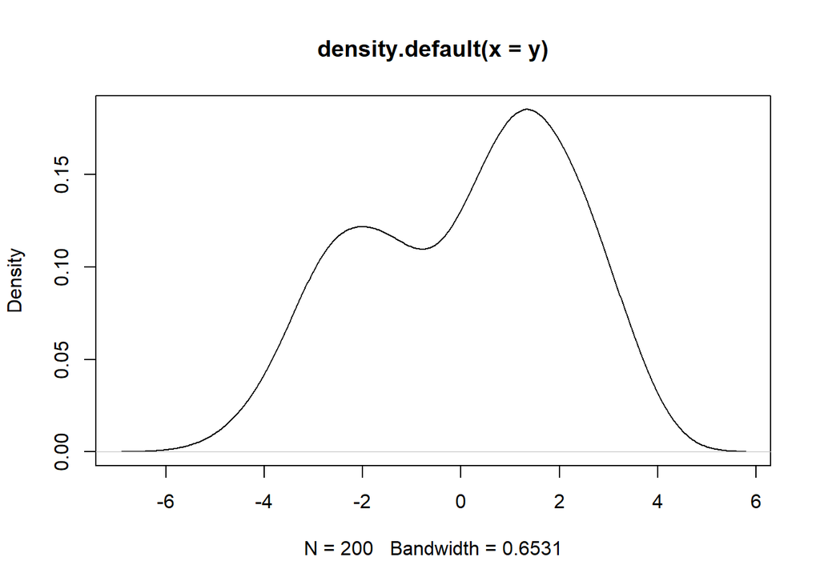

```r
y = dat$V1

plot(density(y))
```

We can see that this variable is a mixture of two normally distributed variables, or at least can be modeled as such.

```r
mod1_string <- "model{
  for(i in 1:length(y)){
    y[i] ~ dnorm(mu[z[i]], prec)
    z[i] ~ dcat(omega)
  }

  mu[1] ~ dnorm(-1.0, 1.0/100.0)
  mu[2] ~ dnorm(1.0, 1.0/100.0) T(mu[1], )

  prec ~ dgamma(1.0/2.0, 1.0*1.0/2.0)  # Note that 1.0 is the guess sample size and 1.0 guess for the value
  sig = sqrt(1.0/prec)

  omega ~ ddirch(c(1.0, 1.0))
}"
```

Note that the difference here is that `z[i]` comes from a categorical distribution, which you can think of as simply being an extension of a bernoulli distribution, where the number of outcomes is larger than 2.

The parameter for this is drawn from a dirichlet distribution, which takes a vector of shape parameters, theyre similar to using the counts of each part of the distribution like how we might update a beta distribution.

Note that the `T` function in the `mu[2]` distribution binds this mean to be larger than `mu[1]`, otherwise the model might have a hard time identifying the means of this multi modal distribution.

```r
data1_jags <- list(y=y)
params1 <- c("mu", "sig", "omega", "z[1]", "z[31]", "z[49]", "z[6]")

mod1 <- jags.model(textConnection(mod1_string), data=data1_jags, n.chains=3)
update(mod1, 1e3)

mod1_sim <- coda.samples(mod1, variable.names=params1, 1e3)
mod1_csim <- as.mcmc(do.call(rbind, mod1_sim))
```

For the parameters that we want to measure, we choose specific values for `z` which we think will be in one normal distribution more often than another or will be in between the two. We don’t want to monitor all of the `z`s because that would be a lot for one person to take in.

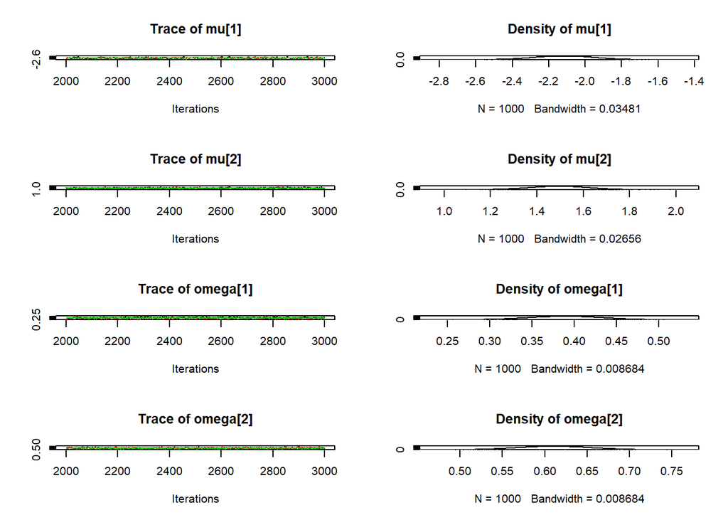

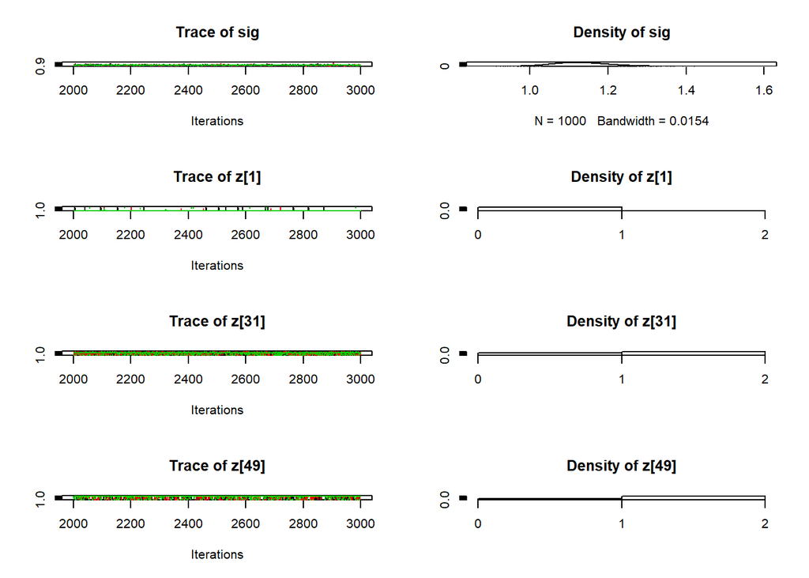

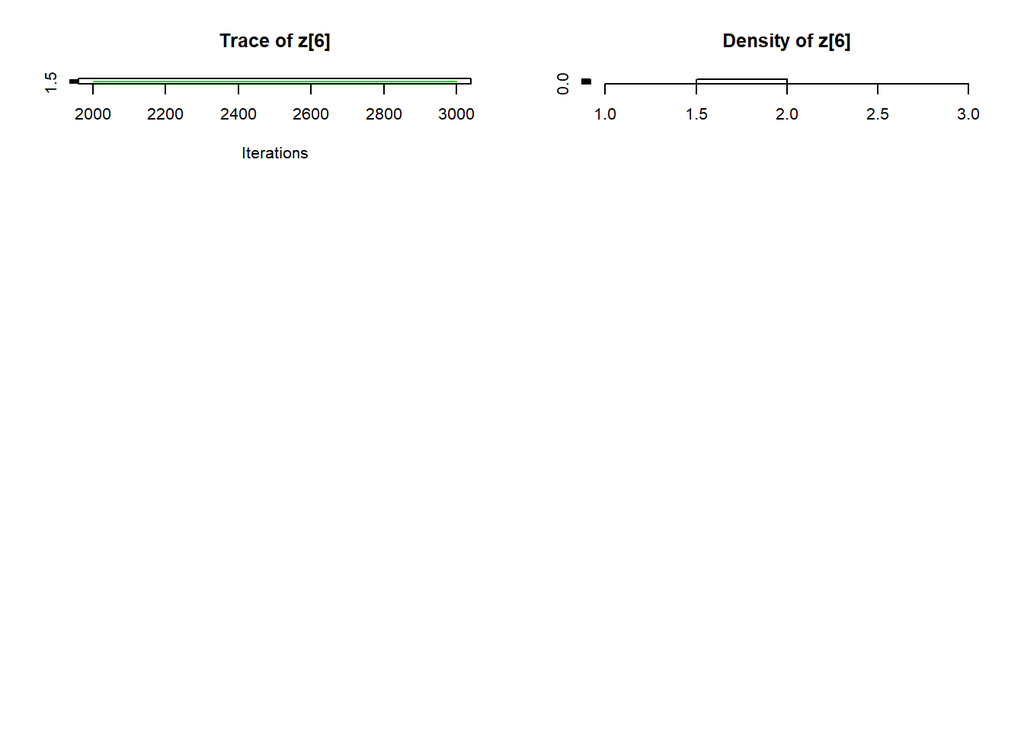

```r
plot(mod1_sim)
```

```r
summary(mod1_sim)
```

```
##
## Iterations = 2001:3000
## Thinning interval = 1
## Number of chains = 3
## Sample size per chain = 1000
##
## 1. Empirical mean and standard deviation for each variable,
##    plus standard error of the mean:
##
##             Mean      SD  Naive SE Time-series SE
## mu[1]    -2.1187 0.16288 0.0029738       0.005762
## mu[2]     1.4929 0.12425 0.0022684       0.003691
## omega[1]  0.3888 0.04063 0.0007418       0.001171
## omega[2]  0.6112 0.04063 0.0007418       0.001171
## sig       1.1337 0.07408 0.0013526       0.002244
## z[1]      1.0103 0.10114 0.0018466       0.001846
## z[31]     1.5877 0.49234 0.0089888       0.009038
## z[49]     1.7990 0.40081 0.0073178       0.007318
## z[6]      2.0000 0.00000 0.0000000       0.000000
##
## 2. Quantiles for each variable:
##
##             2.5%     25%     50%     75%   97.5%
## mu[1]    -2.4404 -2.2298 -2.1160 -2.0052 -1.8094
## mu[2]     1.2497  1.4078  1.4943  1.5752  1.7315
## omega[1]  0.3084  0.3609  0.3887  0.4167  0.4669
## omega[2]  0.5331  0.5833  0.6113  0.6391  0.6916
## sig       1.0031  1.0830  1.1291  1.1795  1.2941
## z[1]      1.0000  1.0000  1.0000  1.0000  1.0000
## z[31]     1.0000  1.0000  2.0000  2.0000  2.0000
## z[49]     1.0000  2.0000  2.0000  2.0000  2.0000
## z[6]      2.0000  2.0000  2.0000  2.0000  2.0000
```

`mu[1]` has a posterior mean of roughly -2.1, which looks to be about right. Same goes for the posterior mean for `mu[2]`.

The values for omega dictate the proportion between the two means, which looks to be a vector of `[0.4, 0.6]`

Let’s take a look at the posterior means for `z` via a graph.

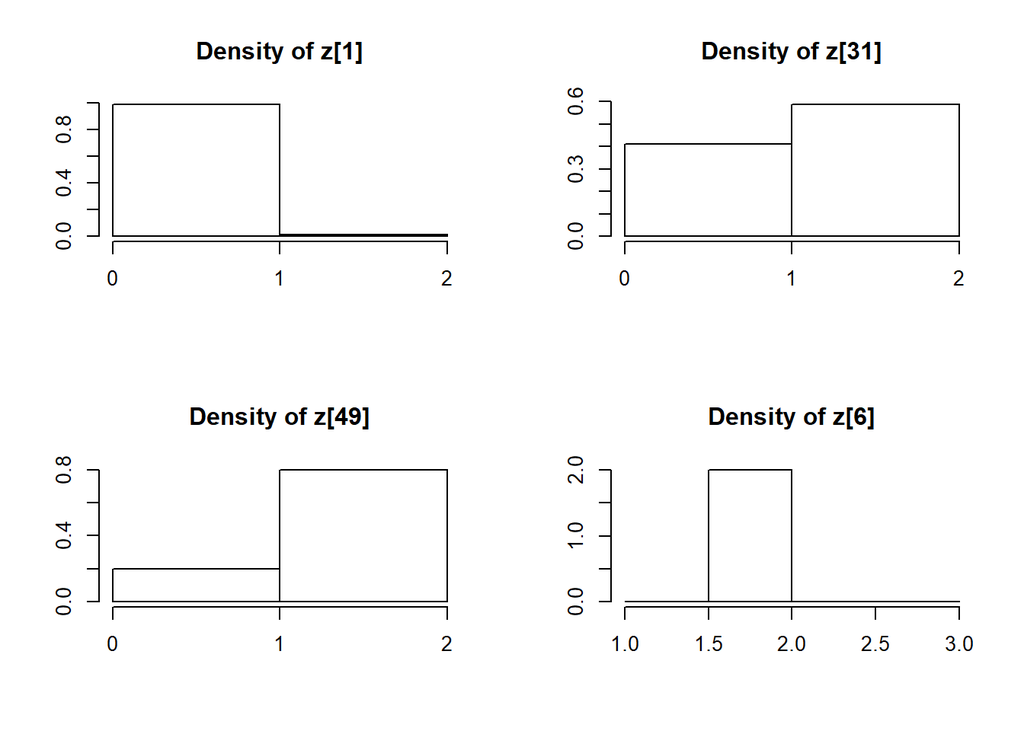

```r
par(mfrow=c(2, 2))
densplot(mod1_csim[,c("z[1]", "z[31]", "z[49]", "z[6]")])
```